# Brightwork Time Tracking Productivity and Project Pipeline Capacity Model

# *How do we utilize our time and what is our future projects load?*

## Assumption:

Accuracy of analysis is highly dependent on data entered in BrightWork. Time frame of analyzed data is from Jul 1 2017 until last 2 weeks of current date. This time frame provides optimal data quality and volume.

## Productivity Model of Epic and IT (Time Series analysis from Jul 2017 to current)

```r
## dataset
utilTimeSeries <- sqlQuery(dataConn,"select WeekEndingDate TimePeriod, Division_Name, sum(Recorded_Hours) TotalHours
from Hour_Summary_Details where WeekEndingDate > '2017-07-01' and WeekEndingDate <
dateadd(week,-2,getdate())
group by WeekEndingDate, Division_Name
order by WeekEndingDate")
```

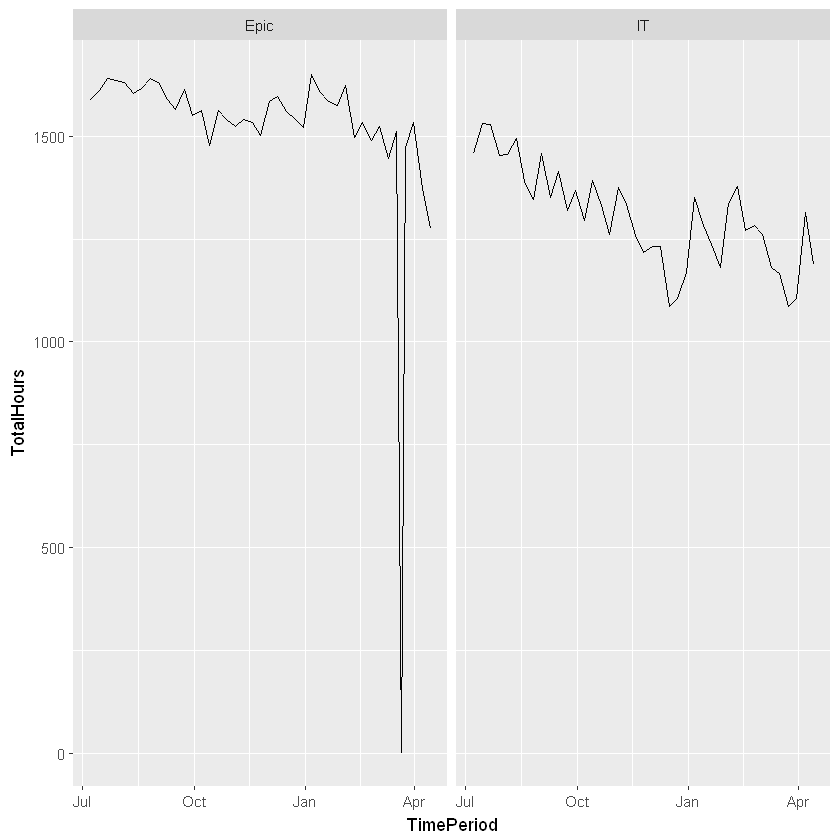

```r
## build time series model
library(ggplot2)
require(ggplot2)
ggplot(utilTimeSeries, aes(x = TimePeriod, y = TotalHours, group = Division_Name)) +
    geom_line() +facet_wrap( ~ Division_Name)
```

## Productivity Model of each IT Team

- Solid blue line is regression model with 95% confidence interval. Data point is grouped by work type (Admin, Project and Ticket).

```r
## data set
utilTimeSeriesIT <- sqlQuery(dataConn,"select WeekEndingDate TimePeriod, Division_Name, Team_Name, Group_Name, Work_Type,
sum(Recorded_Hours) TotalHours
from Hour_Summary_Details where WeekEndingDate > '2017-07-01' and WeekEndingDate <
dateadd(week,-2,getdate()) and Division_Name='IT'
group by WeekEndingDate, Division_Name, Team_Name, Group_Name, Work_Type
order by WeekEndingDate")
```

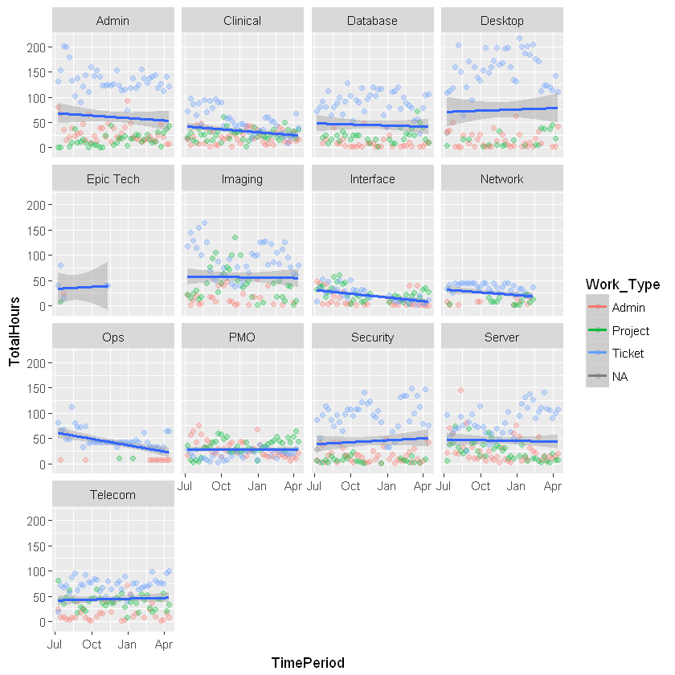

```r
## build time series model
ggplot(utilTimeSeriesIT, aes(x = TimePeriod, y = TotalHours, group = Group_Name, colour=Work_Type)) +
    geom_point(alpha=0.3) +facet_wrap( ~ Group_Name)+ geom_smooth(method="lm", se=TRUE)
```

## Productivity Model of each Epic Team

- Solid blue line is regression model with 95% confidence interval. Data point is grouped by work type (Admin, Project and Ticket).

```r
## data set
utilTimeSeriesEpic <- sqlQuery(dataConn,"select WeekEndingDate TimePeriod, Division_Name, Team_Name, Group_Name,Work_Type,sum(Recorded_Hours) TotalHours
from Hour_Summary_Details where WeekEndingDate > '2017-07-01' and WeekEndingDate <
dateadd(week,-2,getdate()) and Division_Name='Epic'
group by WeekEndingDate, Division_Name, Team_Name, Group_Name, Work_Type
order by WeekEndingDate")
```

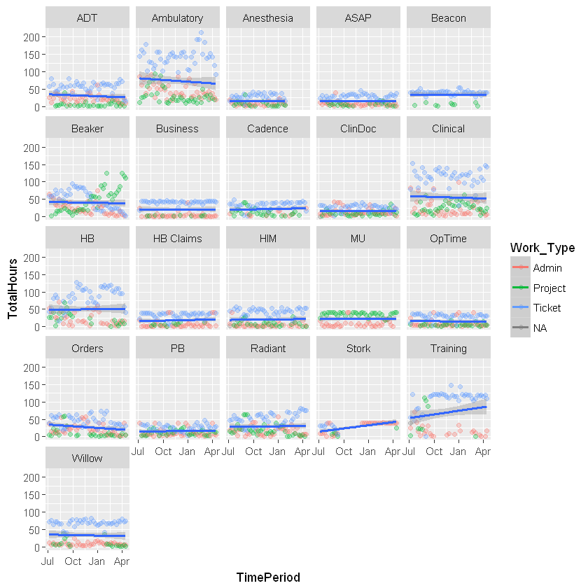

```r
## build time series model
ggplot(utilTimeSeriesEpic, aes(x = TimePeriod, y = TotalHours, group = Group_Name, colour=Work_Type)) +
    geom_point(alpha=0.3) +facet_wrap( ~ Group_Name)+ geom_smooth(method="lm", se=TRUE)
```

## Total Productivity vs Project Hours Usage for Epic and IT

```r
## data set
utilTimeSeriesAllType <- sqlQuery(dataConn,"select WeekEndingDate TimePeriod, Division_Name, sum(Recorded_Hours) TotalHours, Type='All'
from Hour_Summary_Details where WeekEndingDate > '2017-07-01' and WeekEndingDate <
dateadd(week,-2,getdate())
group by WeekEndingDate, Division_Name
union all
select WeekEndingDate, Division_Name, sum(Recorded_Hours) TotalHours, Type='Project'
from Hour_Summary_Details where WeekEndingDate > '2017-07-01' and WeekEndingDate <
dateadd(week,-2,getdate()) and work_type='Project'
group by WeekEndingDate, Division_Name
order by WeekEndingDate")
```

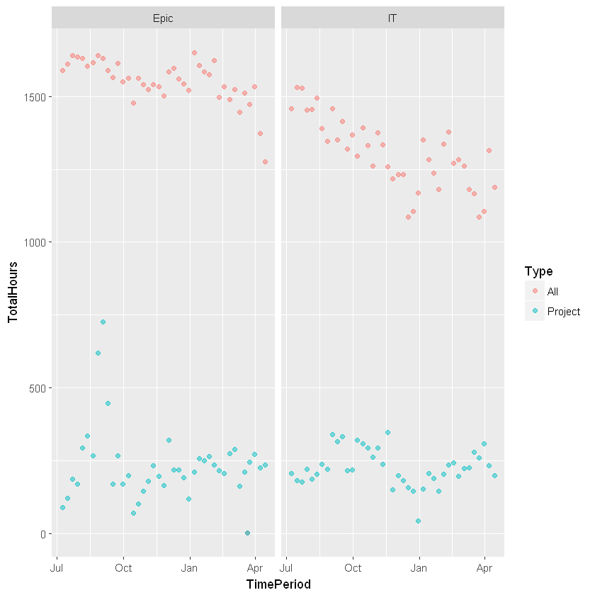

```r
## build time series model
ggplot(utilTimeSeriesAllType, aes(x = TimePeriod, y = TotalHours, group = Division_Name, colour=Type)) +
    geom_point(alpha=0.5) +facet_wrap( ~ Division_Name)
```

## Total Productivity vs Project Hours Usage for IS

- Combined aggregate of Epic and IT

```r
## data set
utilTimeSeriesTotal <- sqlQuery(dataConn,"select WeekEndingDate TimePeriod, sum(Recorded_Hours) TotalHours, Type='All'
from Hour_Summary_Details where WeekEndingDate > '2017-07-01' and WeekEndingDate <
dateadd(week,-2,getdate())
group by WeekEndingDate
union all
select WeekEndingDate,  sum(Recorded_Hours) TotalHours, Type='Project'
from Hour_Summary_Details where WeekEndingDate > '2017-07-01' and WeekEndingDate <
dateadd(week,-2,getdate()) and work_type='Project'
group by WeekEndingDate
order by WeekEndingDate")
```

```r
plot1 <- ggplot(utilTimeSeriesTotal, aes(x = TimePeriod, y = TotalHours, colour=Type)) +
    geom_line()
```

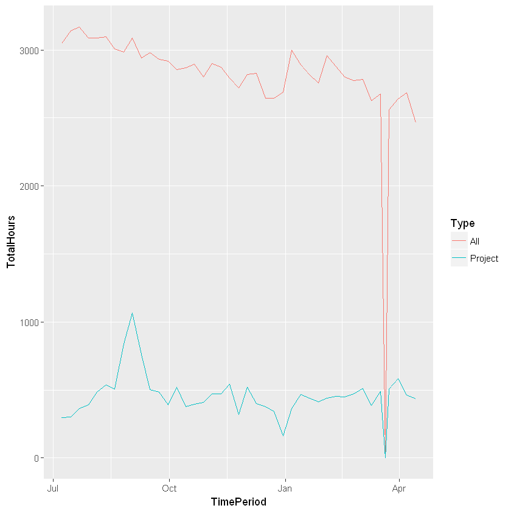

```r
## build time series model
ggplot(utilTimeSeriesTotal, aes(x = TimePeriod, y = TotalHours, colour=Type)) +
    geom_line()
```

```r
utilTimeSeriesProj <- sqlQuery(dataConn,"select [Project SR Name] Project,sum(Recorded_Hours) TotalHours
from Hour_Summary_Details where WeekEndingDate > '2017-07-01' and WeekEndingDate <
dateadd(week,-2,getdate())  and Work_Type='Project'
group by [Project SR Name] having sum(recorded_hours) > 80")
```

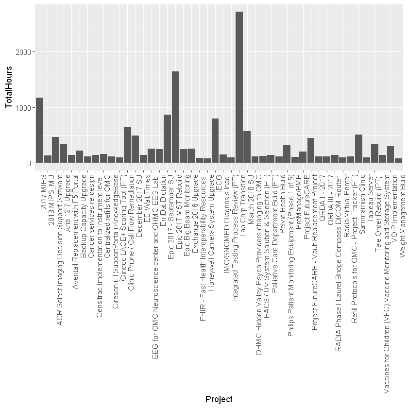

```r
qplot(Project, data=utilTimeSeriesProj, geom="bar", weight=TotalHours) + scale_y_continuous("TotalHours") + theme(axis.text.x = element_text(angle = 90, hjust=1))
```

# Project Pipeline FY 19

### Projected Usage for FY 19 Projects by Department - *which department will consume most IS hours?*

```r
utilProjPipeLine <- sqlQuery(dataConn,"select * from stat_projectpipeline")
```

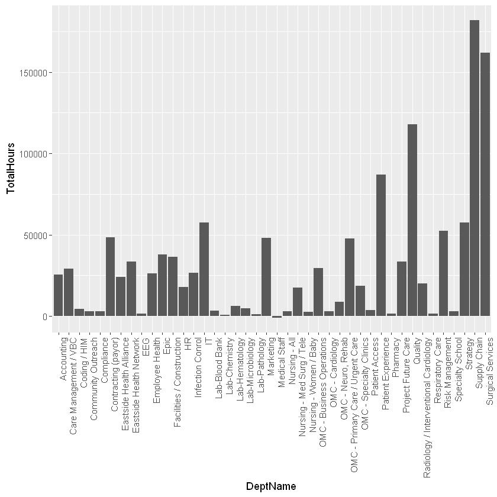

```r
qplot(DeptName, data=utilProjPipeLine, geom="bar", weight=TotalHours) + scale_y_continuous("TotalHours") + theme(axis.text.x = element_text(angle = 90, hjust=1))
```

## Top 25 FY19 Project Hours usage

```r
utilProjPipeLine50 <- sqlQuery(dataConn,"select top 25 * from stat_projectpipeline order by totalhours desc")
```

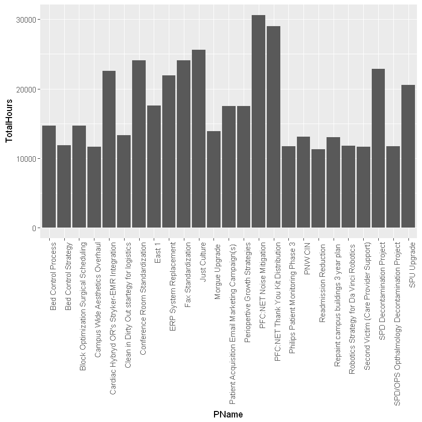

```r
qplot(PName, data=utilProjPipeLine50, geom="bar", weight=TotalHours) + scale_y_continuous("TotalHours") + theme(axis.text.x = element_text(angle = 90, hjust=1))
```

## Projected Usage Model of Project Hours in FY19

```r
## data set
utilProjPipeLineAll <- sqlQuery(dataConn,"select startmonth timeperiod, sum(avgmonthhours) totalhours from stat_ProjectPipelineAvg
group by startmonth")
```

```r
plot2 <- ggplot(utilProjPipeLineAll, aes(x = timeperiod, y = totalhours)) +
    geom_point()+theme(axis.text.x = element_text(angle = 90, hjust=1))
```

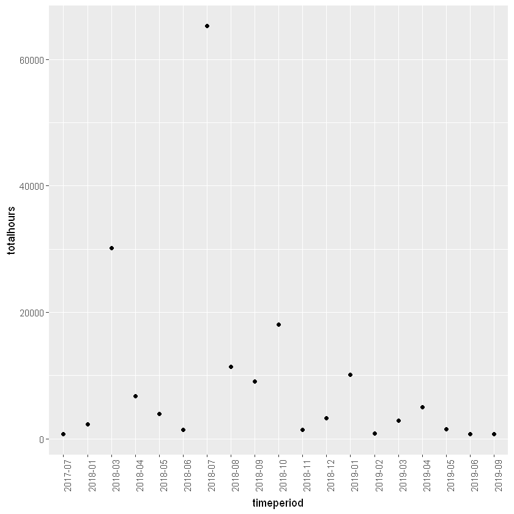

```r
## build time series model
ggplot(utilProjPipeLineAll, aes(x = timeperiod, y = totalhours)) +
    geom_point()+theme(axis.text.x = element_text(angle = 90, hjust=1))
```

# FY 18 Productivity Model vs FY19 Project Hours Usage Model

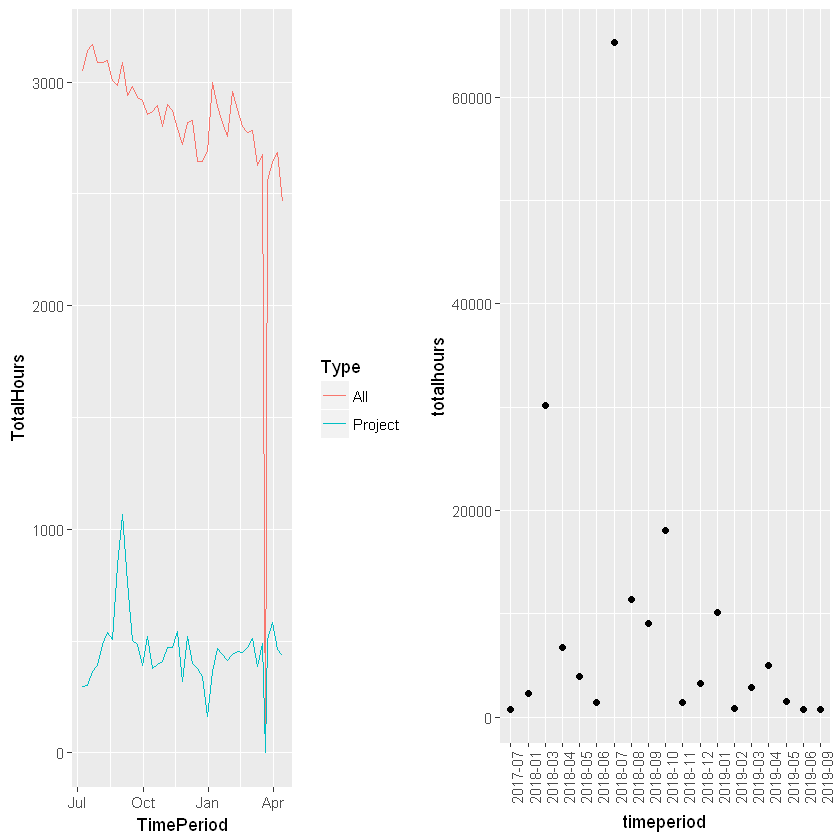

```r
require(gridExtra)
grid.arrange(plot1, plot2, ncol=2)
```

#### For questions and feedbacks:

- *please contact* enterprisedatamanagement@ohmc.org

#### Copyright 2018, Enterprise Data Management. All rights reserved.